# Practical Machine Learning

Luis Rincones

6 June 2016

## Preparation

Prepare two data frames one for each file(training and testing)

Background for the variable classe It corresponds to Unilateral Dumbbell Biceps Curl in five different fashions: according to the specification (Class A), throwing the elbows to the front (Class B), lifting the dumbbell only halfway (Class C), lowering the dumbbell only halfway (Class D) and throwing the hips to the front (Class E). Class A corresponds to the specified execution of the exercise, while the other 4 classes correspond to common mistakes. Generate an Histogram to see the frequencies of the classe variable.

Eliminate the features with NA, from both sets(training and testing) Eliminate some features that don’t contribute to the model we are planning to create

## Summary

After reviewing the available information in the site for the “Human Activity Recognition”, in particular the document available in “http://groupware.les.inf.puc-rio.br/public/papers/2013.Velloso.QAR-WLE.pdf”. The strategy was based in generating 4 subsets one for each sensor; ARM, BELT, DUMBBELLL and FOREARM. The goal was to seek the features that were common among all sensors with a significant contribution to their corresponding model. With this set of features, a new model will be created for prediction. Our requirements were to have a much smaller set of features than the original 159 (without classe). We would like to have fewer than 16 (an empiric number to make the computational times acceptable)

## Libraries

```r
library(caret)
library(randomForest)
```

## Preparation

After downloading the files and creating the Data Frames, generate an Histogram of the Variable classe for the training set.

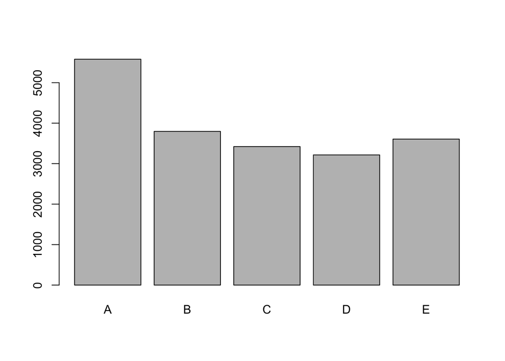

```r
set.seed(1947)
download.file("https://d396qusza40orc.cloudfront.net/predmachlearn/pml-training.csv", "training.csv")
download.file("https://d396qusza40orc.cloudfront.net/predmachlearn/pml-testing.csv", "testing.csv")
training = read.csv("training.csv")
testing = read.csv("testing.csv")
barplot(summary(training$classe))
```

```r
count_na <-sapply(training, function(y) sum(length(which(is.na(y)))))
list_na <- which(count_na > 0)
training_small <- training[,-list_na]
testing_small <- testing[,-list_na]
training_small <- training_small[,-c(1,3:7)]
testing_small <- testing_small[,-c(1,3:7)]
nombres <- colnames(training_small)
```

## Sensors Data Frame

As indicated before we will divide the training Data Frame in 4 sets with a smaller number of features each.

```r
### Recall RandomForest
### Can not handle categorical predictors with more than 53 categories.
# Sensor ARM
temp <- grep("_arm",nombres, ignore.case = TRUE)
temp <- append(temp, 87, after=length(temp))
t_arm <- training_small[,temp]
count_factors <- sapply(t_arm, function(y) which(nlevels(y) <= 50))
count_factors <- as.logical(count_factors)
count_factors[is.na(count_factors)] <- FALSE
t_arm_small <- t_arm[,count_factors]
t_arm_modFit <- randomForest(classe ~ ., t_arm_small, importance=TRUE)
# Sensor BELT
temp <- grep("_belt",nombres, ignore.case = TRUE)
temp <- append(temp, 87, after=length(temp))
t_belt <- training_small[,temp]
count_factors <- sapply(t_belt, function(y) which(nlevels(y) <= 50))
count_factors <- as.logical(count_factors)
count_factors[is.na(count_factors)] <- FALSE
t_belt_small <- t_belt[,count_factors]
t_belt_modFit <- randomForest(classe ~ ., t_belt_small, importance=TRUE)
# SENSOR DUMBBELLL
temp <- grep("_dumbbell",nombres, ignore.case = TRUE)
temp <- append(temp, 87, after=length(temp))
t_dumbbell <- training_small[,temp]
count_factors <- sapply(t_dumbbell, function(y) which(nlevels(y) <= 50))
count_factors <- as.logical(count_factors)
count_factors[is.na(count_factors)] <- FALSE
t_dumbbell_small <- t_dumbbell[,count_factors]
t_dumbbell_modFit <- randomForest(classe ~ ., t_dumbbell_small, importance=TRUE)
# SENSOR FOREARM
temp <- grep("_forearm",nombres, ignore.case = TRUE)
temp <- append(temp, 87, after=length(temp))
t_forearm <- training_small[,temp]
t_forearm <- training_small[,temp]
count_factors <- sapply(t_forearm, function(y) which(nlevels(y) <= 50))
count_factors <- as.logical(count_factors)
count_factors[is.na(count_factors)] <- FALSE
t_forearm_small <- t_forearm[,count_factors]
t_forearm_modFit <- randomForest(classe ~ ., t_dumbbell_small, importance=TRUE)
```

## Analysis

```r
# Listing and Analyzing the features for each sensor's model
sort(t_arm_modFit$importance[,7], decreasing = TRUE)
```

```
##        roll_arm       pitch_arm    magnet_arm_y     accel_arm_z
##       1720.1569       1536.3274       1310.5750       1270.9586
##     accel_arm_x     gyros_arm_x         yaw_arm     accel_arm_y
##       1252.2595       1214.7045       1207.8117       1137.6990
##    magnet_arm_x    magnet_arm_z     gyros_arm_y     gyros_arm_z
##       1135.8495       1116.9050       1109.3780        780.5063
## total_accel_arm
##        711.9776
```

```r
sort(t_belt_modFit$importance[,7], decreasing = TRUE)
```

```
##           yaw_belt          roll_belt         pitch_belt
##        2782.277719        2542.377062        2431.801487
##      magnet_belt_z      magnet_belt_x       accel_belt_z
##        1153.712177        1140.890074        1093.722168
##      magnet_belt_y       gyros_belt_z       gyros_belt_x
##         929.434523         842.218195         678.324468
##       accel_belt_x       accel_belt_y       gyros_belt_y
##         665.344422         452.325353         389.975824
##   total_accel_belt amplitude_yaw_belt  skewness_yaw_belt
##         381.582793           6.974285           6.806856
##  kurtosis_yaw_belt
##           6.662137
```

```r
sort(t_dumbbell_modFit$importance[,7], decreasing = TRUE)
```

```
##      magnet_dumbbell_z      magnet_dumbbell_y      magnet_dumbbell_x
##            2602.824426            1811.853996            1528.535732
##       accel_dumbbell_z       accel_dumbbell_y       gyros_dumbbell_y
##            1288.742407            1146.505316            1102.754306
##          roll_dumbbell           yaw_dumbbell       gyros_dumbbell_x
##            1085.925055             889.959352             862.975661
##   total_accel_dumbbell       accel_dumbbell_x         pitch_dumbbell
##             849.874367             798.822558             776.319077
##       gyros_dumbbell_z  kurtosis_yaw_dumbbell amplitude_yaw_dumbbell
##             693.740856               5.391307               5.239492
##  skewness_yaw_dumbbell
##               5.206067
```

```r
sort(t_forearm_modFit$importance[,7], decreasing = TRUE)
```

```
##      magnet_dumbbell_z      magnet_dumbbell_y      magnet_dumbbell_x
##            2581.662152            1832.210619            1538.067876
##       accel_dumbbell_z       accel_dumbbell_y       gyros_dumbbell_y
##            1277.299596            1123.995936            1104.759780
##          roll_dumbbell           yaw_dumbbell       gyros_dumbbell_x
##            1099.798980             889.528859             871.290392
##   total_accel_dumbbell         pitch_dumbbell       accel_dumbbell_x
##             865.124586             780.282486             776.677311
##       gyros_dumbbell_z amplitude_yaw_dumbbell  kurtosis_yaw_dumbbell
##             696.887315               5.259698               5.211563
##  skewness_yaw_dumbbell
##               5.142593
```

```r
colnames(t_arm_small)
```

```
##  [1] "roll_arm"        "pitch_arm"       "yaw_arm"
##  [4] "total_accel_arm" "gyros_arm_x"     "gyros_arm_y"
##  [7] "gyros_arm_z"     "accel_arm_x"     "accel_arm_y"
## [10] "accel_arm_z"     "magnet_arm_x"    "magnet_arm_y"
## [13] "magnet_arm_z"    "classe"
```

```r
colnames(t_belt_small)
```

```
##  [1] "roll_belt"          "pitch_belt"         "yaw_belt"
##  [4] "total_accel_belt"   "kurtosis_yaw_belt"  "skewness_yaw_belt"
##  [7] "amplitude_yaw_belt" "gyros_belt_x"       "gyros_belt_y"
## [10] "gyros_belt_z"       "accel_belt_x"       "accel_belt_y"
## [13] "accel_belt_z"       "magnet_belt_x"      "magnet_belt_y"
## [16] "magnet_belt_z"      "classe"
```

```r
colnames(t_dumbbell_small)
```

```
##  [1] "roll_dumbbell"          "pitch_dumbbell"
##  [3] "yaw_dumbbell"           "kurtosis_yaw_dumbbell"
##  [5] "skewness_yaw_dumbbell"  "amplitude_yaw_dumbbell"
##  [7] "total_accel_dumbbell"   "gyros_dumbbell_x"
##  [9] "gyros_dumbbell_y"       "gyros_dumbbell_z"
## [11] "accel_dumbbell_x"       "accel_dumbbell_y"
## [13] "accel_dumbbell_z"       "magnet_dumbbell_x"
## [15] "magnet_dumbbell_y"      "magnet_dumbbell_z"
## [17] "classe"
```

```r
colnames(t_forearm_small)
```

```
##  [1] "roll_forearm"          "pitch_forearm"
##  [3] "yaw_forearm"           "kurtosis_yaw_forearm"
##  [5] "skewness_yaw_forearm"  "max_yaw_forearm"
##  [7] "min_yaw_forearm"       "amplitude_yaw_forearm"
##  [9] "total_accel_forearm"   "gyros_forearm_x"
## [11] "gyros_forearm_y"       "gyros_forearm_z"
## [13] "accel_forearm_x"       "accel_forearm_y"
## [15] "accel_forearm_z"       "magnet_forearm_x"
## [17] "magnet_forearm_y"      "magnet_forearm_z"
## [19] "classe"
```

```r
t_arm_rfcv <- rfcv(trainx=t_arm_small[,-14], trainy = t_arm_small[,14], scale = "log", step=0.5)
t_belt_rfcv <- rfcv(trainx=t_belt_small[,-17], trainy = t_belt_small[,17], scale = "log", step=0.5)
t_dumbbell_rfcv <- rfcv(trainx=t_dumbbell_small[,-17], trainy = t_dumbbell_small[,17], scale = "log", step=0.5)
t_forearm_rfcv <- rfcv(trainx=t_forearm_small[,-19], trainy = t_forearm_small[,19], scale = "log", step=0.5)
```

## Final Model

```r
# after analysis the features chosen as a common group were
temp1 <- grep("magnet",nombres, ignore.case = TRUE)
temp1 <- grep("magnet",nombres, ignore.case = TRUE)
temp1 <- append(temp1, 87, after=length(temp1))
t_final <- training_small[,temp1]
dim(t_final)
```

```
## [1] 19622    13
```

```r
colnames(t_final)
```

```
##  [1] "magnet_belt_x"     "magnet_belt_y"     "magnet_belt_z"
##  [4] "magnet_arm_x"      "magnet_arm_y"      "magnet_arm_z"
##  [7] "magnet_dumbbell_x" "magnet_dumbbell_y" "magnet_dumbbell_z"
## [10] "magnet_forearm_x"  "magnet_forearm_y"  "magnet_forearm_z"
## [13] "classe"
```

```r
t_final_modFit <- randomForest(classe ~ ., t_final, importance=TRUE)
t_final_modFit$confusion
```

```
##      A    B    C    D    E class.error
## A 5532   17   11   16    4 0.008602151
## B  102 3587   49   38   21 0.055306821
## C   21   51 3328   14    8 0.027469316
## D   28   12   90 3067   19 0.046330846
## E    8   30   17   30 3522 0.023565290
```

```r
t_final_modFit$importance
```

```
##                           A          B          C          D          E
## magnet_belt_x     0.1378058 0.14624219 0.15808035 0.21913892 0.08587806
## magnet_belt_y     0.1408096 0.15231764 0.18755163 0.21039402 0.19030819
## magnet_belt_z     0.1586239 0.18185313 0.20388370 0.22883656 0.16490680
## magnet_arm_x      0.2166282 0.09620763 0.13318798 0.16086667 0.08429880
## magnet_arm_y      0.1338848 0.11290374 0.13898982 0.18946886 0.09248110
## magnet_arm_z      0.1134260 0.08920900 0.08366583 0.07212268 0.04389458
## magnet_dumbbell_x 0.2913579 0.19858214 0.30809218 0.26859646 0.13701659
## magnet_dumbbell_y 0.2735148 0.23008786 0.31988456 0.26645577 0.14720893
## magnet_dumbbell_z 0.2973680 0.23391981 0.32222205 0.32947302 0.16220276
## magnet_forearm_x  0.1999252 0.07404572 0.11073831 0.13976640 0.10660586
## magnet_forearm_y  0.1299058 0.08172935 0.11683743 0.11416196 0.07053082
## magnet_forearm_z  0.1195485 0.09657979 0.12719856 0.14389430 0.07393205
##                   MeanDecreaseAccuracy MeanDecreaseGini
## magnet_belt_x               0.14673088        1280.6762
## magnet_belt_y               0.17168533        1466.5473
## magnet_belt_z               0.18364143        1567.4332
## magnet_arm_x                0.14528848         932.8538
## magnet_arm_y                0.13219556         966.6756
## magnet_arm_z                0.08398821         812.4728
## magnet_dumbbell_x           0.24418122        1616.1607
## magnet_dumbbell_y           0.24878596        1755.4010
## magnet_dumbbell_z           0.26979029        2141.3803
## magnet_forearm_x            0.13298110        1022.1820
## magnet_forearm_y            0.10478723         891.0254
## magnet_forearm_z            0.11201122        1060.0730
```

```r
t_rfcv <- rfcv(trainx=t_final[,-13], trainy = t_final[,13], scale = "log", step=0.7)
t_rfcv$error.cv
```

```
##         12          8          6          4          3          2
## 0.03338090 0.06462134 0.09519927 0.21501376 0.32325961 0.38222403
##          1
## 0.59642238
```

## Prediction

As required the prediction using the testing as newdata. Results are indicate below.

```r
t_prediction <- predict(t_final_modFit, newdata = testing_small)
t_prediction
```

```
##  1  2  3  4  5  6  7  8  9 10 11 12 13 14 15 16 17 18 19 20
##  B  A  B  A  A  E  D  B  A  A  B  C  B  A  E  E  A  B  B  B
## Levels: A B C D E
```